# Time Series Lab 1

Montsie Guerrero

9/26/2019

1. Conduct a trend analysis of some variable of interest. Graph it and try different functional forms. Look for subgroup variation across time, too.

How has belief in the existence of God changed across time in the USA? In particular, I would like to explore the variable **god** from the GSS which answers the question, “Which statement comes closest to expressing what you believe about God?”. Responses were made on a 1-6 scale: I don’t believe in God (1), I don’t now whether there is a God, and I don’t believe there is any way to find out (2), I don’t believe in a personal God, but do believe in a Higher Power of some kind (3), I find myself believing in God some of the time, but not at others (4), While I have doubts, I feel that I do believe in God (5), I know God really exists and I have no doubts about it (6).

```r
Tab(sub$god)
```

```
##   Count   Pct Cum.Pct
## 1   460  2.71    2.71
## 2   779  4.59    7.30
## 3  1613  9.50   16.80
## 4   709  4.18   20.98
## 5  2785 16.40   37.38
## 6 10631 62.62  100.00
```

For all the years (1988-2012), about 62.62% of respondents do believe in God and have no doubts about it. But how does this change throughout the years?

# Data Visualization of Belief in God (1988-2012)

Across time, belief in God has fluctuated as illustrated by the graph:

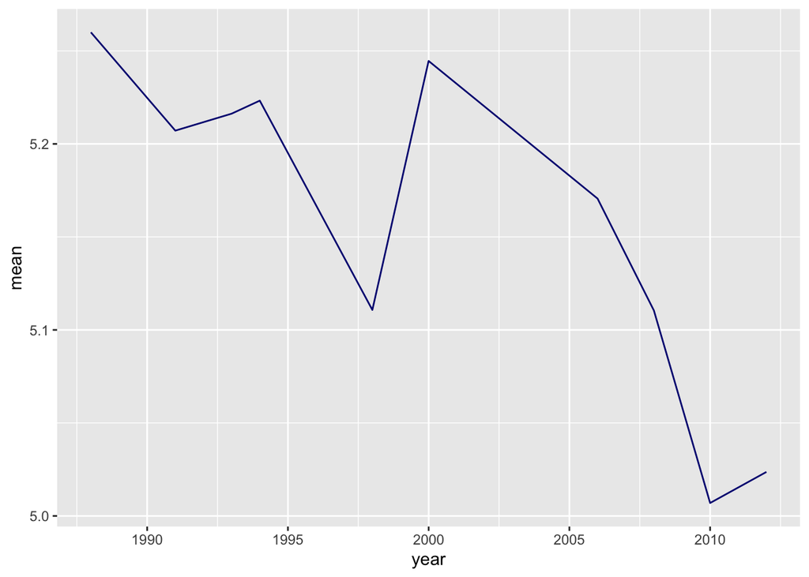

```r
sub <- na.omit(sub)
library(plyr)
by.year <- ddply(sub,"year", summarize, mean = mean(god))
library(ggplot2)
g_by.year <- ggplot(by.year, aes(x=year, y=mean)) + geom_line(color = "navyblue")
g_by.year
```

As shown, belief in God has declined in the US since 1988 until the late 1990s. There is a sudden rise in the graph from around 1998-2000 then a gradual decline from that year on until 2010.

# Linear Regression

I will first try to fit a linear regressionnmodel to try to explain the data.

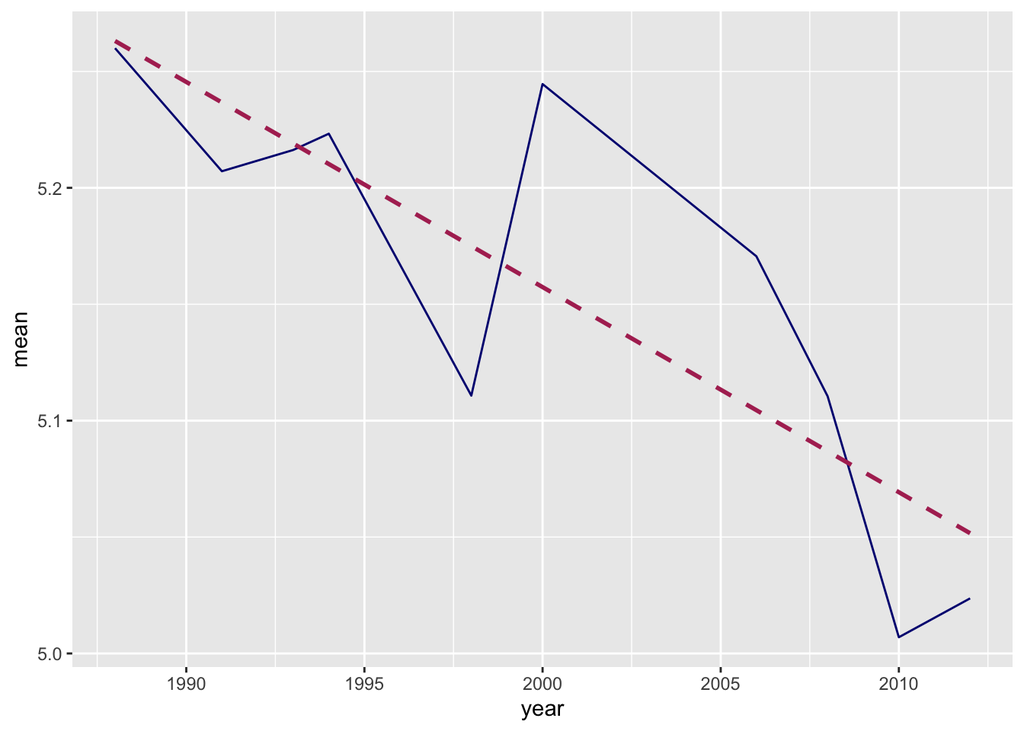

```r
g_by.year + stat_smooth(method = "lm", se = FALSE, color = "maroon", lty = 2)
```

# Linear Regression (Fitting a Line)

```r
lm.god <- lm(god ~ year, data = sub)
summary(lm.god)
```

```
##
## Call:
## lm(formula = god ~ year, data = sub)
##
## Residuals:
##     Min      1Q  Median      3Q     Max
## -4.2657 -0.2218  0.7782  0.8921  0.9447
##
## Coefficients:
##              Estimate Std. Error t value Pr(>|t|)
## (Intercept) 22.695739   2.591395   8.758  < 2e-16 ***
## year        -0.008768   0.001295  -6.772 1.31e-11 ***
## ---
## Signif. codes:  0 '***' 0.001 '**' 0.01 '*' 0.05 '.' 0.1 ' ' 1
##
## Residual standard error: 1.368 on 16862 degrees of freedom
## Multiple R-squared:  0.002712,   Adjusted R-squared:  0.002653
## F-statistic: 45.86 on 1 and 16862 DF,  p-value: 1.311e-11
```

This model shows that with each year that passes, there is a 0.008 point decrease in the belief in God (on a 6 point scale). The p-value is statistically significant (p<0.05). The adjusted R-sq is 0.002 meaning the model can explain 0.2% of the variation in belief in God with the time trend, which is quite low.

# Test for Heteroskedasticity

```r
library(lmtest)
bptest(lm.god)
```

```
##
##  studentized Breusch-Pagan test
##
## data:  lm.god
## BP = 35.914, df = 1, p-value = 2.062e-09
```

With a p-value <0.001, the data is significantly heterodeskedastic. This would mean that the variable year is causing heteroskedasticity in the regression. This is important to consider because heteroskedasticity leads to inappropriate standard errors.

# OLS

It would be good to apply robust standard errors.

```r
ols.god <- ols(god ~ year, data = sub, x = T, y= T)
robcov(ols.god)
```

```
## Linear Regression Model
##
##  ols(formula = god ~ year, data = sub, x = T, y = T)
##
##                 Model Likelihood     Discrimination
##                    Ratio Test           Indexes
##  Obs   16864    LR chi2     45.81    R2       0.003
##  sigma1.3678    d.f.            1    R2 adj   0.003
##  d.f.  16862    Pr(> chi2) 0.0000    g        0.080
##
##  Residuals
##
##      Min      1Q  Median      3Q     Max
##  -4.2657 -0.2218  0.7782  0.8921  0.9447
##
##
##            Coef    S.E.   t     Pr(>|t|)
##  Intercept 22.6957 2.5636  8.85 <0.0001
##  year      -0.0088 0.0013 -6.84 <0.0001
##
```

Now, the t-statistic is -6.85 compared to the t-statistic of -6.77 in naive OLS. There is virtually no difference in t-score value.

# Linear Regression with Dummy Variable

```r
ols.god2 <- lm(god ~ as.factor(year), data = sub)
summary(ols.god2)
```

```
##
## Call:
## lm(formula = god ~ as.factor(year), data = sub)
##
## Residuals:
##     Min      1Q  Median      3Q     Max
## -4.2600 -0.2232  0.7768  0.8893  0.9930
##
## Coefficients:
##                     Estimate Std. Error t value Pr(>|t|)
## (Intercept)          5.25999    0.03558 147.846  < 2e-16 ***
## as.factor(year)1991 -0.05285    0.05181  -1.020  0.30766
## as.factor(year)1993 -0.04373    0.05021  -0.871  0.38378
## as.factor(year)1994 -0.03674    0.05201  -0.706  0.47997
## as.factor(year)1998 -0.14924    0.05280  -2.826  0.00471 **
## as.factor(year)2000 -0.01541    0.05373  -0.287  0.77432
## as.factor(year)2006 -0.08937    0.04357  -2.051  0.04028 *
## as.factor(year)2008 -0.14949    0.04695  -3.184  0.00146 **
## as.factor(year)2010 -0.25302    0.04685  -5.400 6.75e-08 ***
## as.factor(year)2012 -0.23632    0.04720  -5.007 5.57e-07 ***
## ---
## Signif. codes:  0 '***' 0.001 '**' 0.01 '*' 0.05 '.' 0.1 ' ' 1
##
## Residual standard error: 1.367 on 16854 degrees of freedom
## Multiple R-squared:  0.003927,   Adjusted R-squared:  0.003395
## F-statistic: 7.382 on 9 and 16854 DF,  p-value: 7.966e-11
```

When dummy variables for year are applied, the model shows that relative to 1988, belief in God dropped by -0.15 points in 1998 (on a 6 point scale). The adjusted R-sq is 0.003, which means the model explains 0.3% of the variation in the belief in God. It is a better model than the simple linear regression but testing other kinds of models may lead to a better fit.

# Linear Hypothesis Test

```r
linearHypothesis(ols.god2, "as.factor(year)2000 = as.factor(year)2010")
```

```
## Linear hypothesis test
##
## Hypothesis:
## as.factor(year)2000 - as.factor(year)2010 = 0
##
## Model 1: restricted model
## Model 2: god ~ as.factor(year)
##
##   Res.Df   RSS Df Sum of Sq      F    Pr(>F)
## 1  16855 31550
## 2  16854 31509  1    41.377 22.133 2.565e-06 ***
## ---
## Signif. codes:  0 '***' 0.001 '**' 0.01 '*' 0.05 '.' 0.1 ' ' 1
```

The F-test for whether belief in God in 2000 (B = -0.016) is different from 2010 (B=-0.252) indicates a change, as the p-value on the F-statistic is highly statistically significant (p<0.001). We rejct the null hypothesis that belief in God in 2000 shows no change compared to 2010.

# Periodization Regression Test

```r
sub$late = ifelse((sub$year>2000), 1, 0)
lm.god.period = lm(god ~ late, data = sub)
summary(lm.god.period)
```

```
##
## Call:
## lm(formula = god ~ late, data = sub)
##
## Residuals:
##     Min      1Q  Median      3Q     Max
## -4.2118 -0.2118  0.7882  0.9119  0.9119
##
## Coefficients:
##             Estimate Std. Error t value Pr(>|t|)
## (Intercept)  5.21183    0.01533 339.925  < 2e-16 ***
## late        -0.12374    0.02111  -5.863 4.63e-09 ***
## ---
## Signif. codes:  0 '***' 0.001 '**' 0.01 '*' 0.05 '.' 0.1 ' ' 1
##
## Residual standard error: 1.368 on 16862 degrees of freedom
## Multiple R-squared:  0.002034,   Adjusted R-squared:  0.001975
## F-statistic: 34.37 on 1 and 16862 DF,  p-value: 4.634e-09
```

# Quadratic Regression

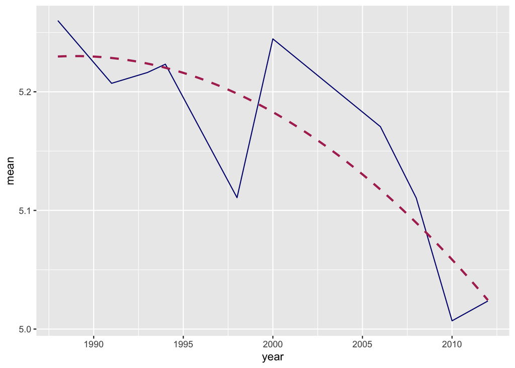

```r
g_by.year + stat_smooth(method = "lm", formula = y ~ poly(x,2), se = FALSE, color = "maroon", lty = 2)
```

# Quadratic Regression Test

```r
lm.ngodsq = lm(god ~ year + I(year^2), data = sub)
summary(lm.ngodsq)
```

```
##
## Call:
## lm(formula = god ~ year + I(year^2), data = sub)
##
## Residuals:
##     Min      1Q  Median      3Q     Max
## -4.2294 -0.2246  0.7739  0.8746  0.9773
##
## Coefficients:
##               Estimate Std. Error t value Pr(>|t|)
## (Intercept) -1.917e+03  9.041e+02  -2.120   0.0340 *
## year         1.931e+00  9.039e-01   2.136   0.0327 *
## I(year^2)   -4.848e-04  2.259e-04  -2.146   0.0319 *
## ---
## Signif. codes:  0 '***' 0.001 '**' 0.01 '*' 0.05 '.' 0.1 ' ' 1
##
## Residual standard error: 1.368 on 16861 degrees of freedom
## Multiple R-squared:  0.002985,   Adjusted R-squared:  0.002866
## F-statistic: 25.24 on 2 and 16861 DF,  p-value: 1.137e-11
```

At first, belief in God rises (indicated by the positive coefficient on year) then declines (inidicated by the negative coefficient in year^2). The adjusted R-sq is 0.002 which is quite low. The adjusted R-sq is 0.002 which is still quite low and may not be the best fit for the data.

# Cubic Regression

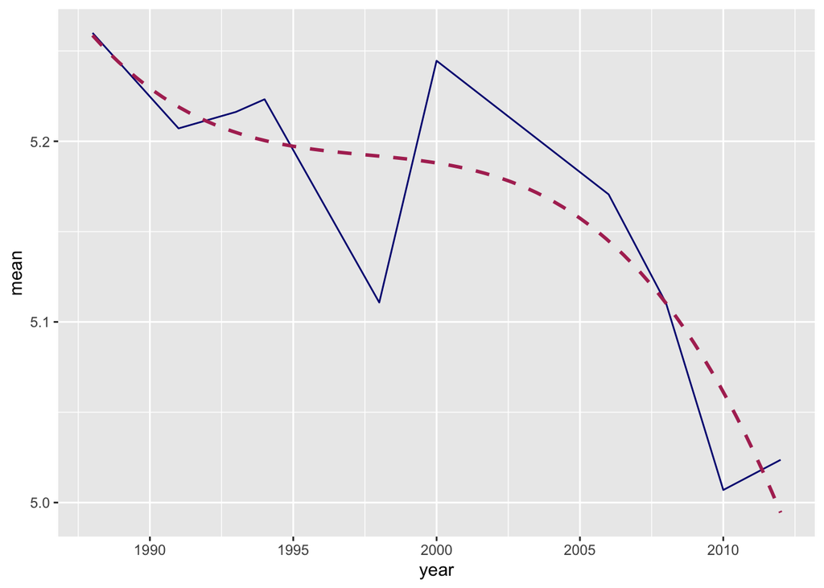

```r
g_by.year + stat_smooth(method = "lm", formula = y ~ poly(x,3), se = FALSE, color = "maroon", lty = 2)
```

# Cubic Regression Test

```r
lm.godcu = lm(god ~ year + I(year^2) + I(year^3), data = sub)
summary(lm.godcu)
```

```
##
## Call:
## lm(formula = god ~ year + I(year^2) + I(year^3), data = sub)
##
## Residuals:
##     Min      1Q  Median      3Q     Max
## -4.2583 -0.2056  0.7944  0.8519  1.0068
##
## Coefficients:
##               Estimate Std. Error t value Pr(>|t|)
## (Intercept)  4.874e+05  2.441e+05   1.997   0.0459 *
## year        -7.321e+02  3.661e+02  -1.999   0.0456 *
## I(year^2)    3.665e-01  1.831e-01   2.002   0.0453 *
## I(year^3)   -6.116e-05  3.051e-05  -2.005   0.0450 *
## ---
## Signif. codes:  0 '***' 0.001 '**' 0.01 '*' 0.05 '.' 0.1 ' ' 1
##
## Residual standard error: 1.368 on 16860 degrees of freedom
## Multiple R-squared:  0.003222,   Adjusted R-squared:  0.003045
## F-statistic: 18.17 on 3 and 16860 DF,  p-value: 9.145e-12
```

# Subgroup Variation Across Time (Political Party)

Does belief in the existence of God differ among people who are affiliated with a political party (over a period of 20 or so years i.e. 1988 to 2012)? I wanted to see the differences in the belief of God among respondents who belong to a particular political party. Here, I filtered out the **partyid** variable, only retaining: Strong Democrat (0), Independent (3), and Republican (6) for purposes of analysis of the 3 main parties.

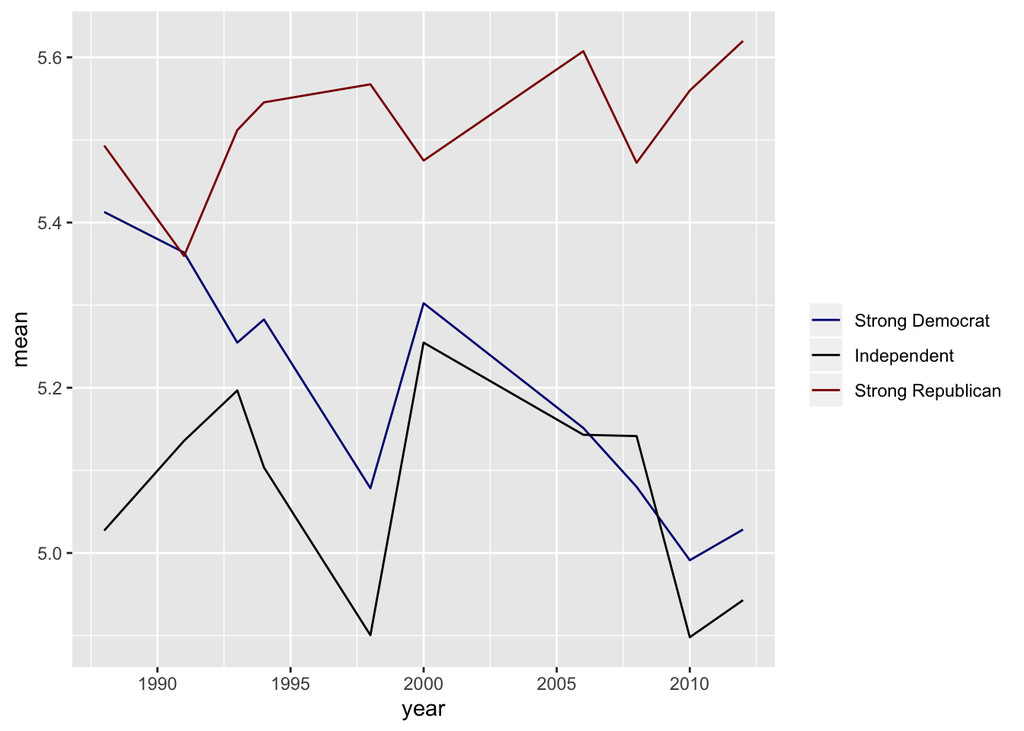

```r
sub2 <- sub %>%
  filter(partyid == 0 | partyid == 3 | partyid == 6)
by.year.partyid <- ddply(sub2, c("year","partyid"), summarise, mean = mean(god, na.rm =T))
colors_and_labels <- scale_color_manual(values = c("navyblue","black", "darkred"), labels = c("Strong Democrat", "Independent","Strong Republican"), name = "")
g_by.year.partyid <- ggplot(by.year.partyid, aes(x=year, y=mean, group=partyid, color=factor(partyid)))
g_by.year.partyid <- g_by.year.partyid + geom_line()
g_by.year.partyid + colors_and_labels
```

# Fitting a line on partyid

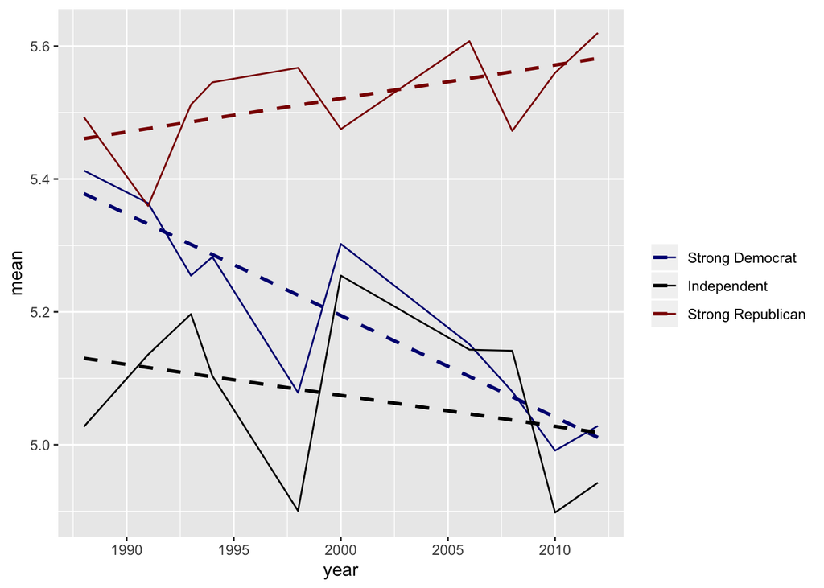

```r
g_linear <- g_by.year.partyid + stat_smooth(method = "lm", se = FALSE, lty = 2)
g_linear + colors_and_labels
```

# Quadratic Fit based on partyid

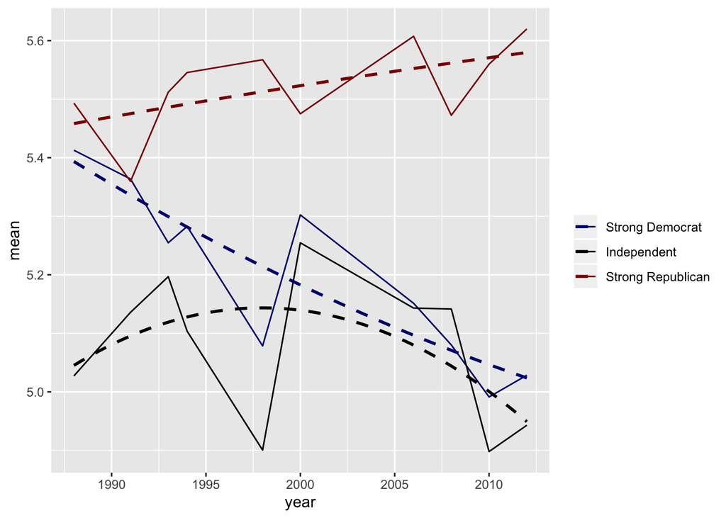

```r
g_quad <- g_by.year.partyid + stat_smooth(method = "lm", formula = y ~ poly(x,2), se = FALSE, lty = 2)
g_quad + colors_and_labels
```

After running regressions for each party, the p-value for year^2 is > 0.05 for Democrat and Republican. Only Independent had p-value <0.05 (statistically significant). But all 3 regressions had low adj. R-sq of 0.007 (Democrat), 0.002 (Independent), and 0.0007 (Republican), suggesting that the quadratic model does not fully explain the variation in the data. (See tests below.)

# Quadratic Regression Tests

*Democrat*

```r
sub2$yearsq = sub2$year*sub2$year
lm_quad = lm(god ~ year + yearsq, sub2, subset= partyid == 0)
summary(lm_quad)
```

```
##
## Call:
## lm(formula = god ~ year + yearsq, data = sub2, subset = partyid ==
##     0)
##
## Residuals:
##     Min      1Q  Median      3Q     Max
## -4.3866 -0.2276  0.6939  0.9234  0.9816
##
## Coefficients:
##               Estimate Std. Error t value Pr(>|t|)
## (Intercept)  1.952e+02  2.368e+03   0.082    0.934
## year        -1.747e-01  2.368e+00  -0.074    0.941
## yearsq       3.983e-05  5.918e-04   0.067    0.946
##
## Residual standard error: 1.421 on 2682 degrees of freedom
## Multiple R-squared:  0.007707,   Adjusted R-squared:  0.006967
## F-statistic: 10.42 on 2 and 2682 DF,  p-value: 3.119e-05
```

*Independent*

```r
sub2$yearsq = sub2$year*sub2$year
lm_quad = lm(god ~ year + yearsq, sub2, subset= partyid == 3)
summary(lm_quad)
```

```
##
## Call:
## lm(formula = god ~ year + yearsq, data = sub2, subset = partyid ==
##     3)
##
## Residuals:
##     Min      1Q  Median      3Q     Max
## -4.1679 -0.1661  0.8592  0.9437  1.0602
##
## Coefficients:
##               Estimate Std. Error t value Pr(>|t|)
## (Intercept) -5.113e+03  2.356e+03  -2.170   0.0301 *
## year         5.122e+00  2.355e+00   2.175   0.0297 *
## yearsq      -1.281e-03  5.886e-04  -2.177   0.0296 *
## ---
## Signif. codes:  0 '***' 0.001 '**' 0.01 '*' 0.05 '.' 0.1 ' ' 1
##
## Residual standard error: 1.433 on 2744 degrees of freedom
## Multiple R-squared:  0.002501,   Adjusted R-squared:  0.001774
## F-statistic: 3.441 on 2 and 2744 DF,  p-value: 0.03218
```

*Republican*

```r
sub2$yearsq = sub2$year*sub2$year
lm_quad = lm(god ~ year + yearsq, sub2, subset= partyid == 6)
summary(lm_quad)
```

```
##
## Call:
## lm(formula = god ~ year + yearsq, data = sub2, subset = partyid ==
##     6)
##
## Residuals:
##     Min      1Q  Median      3Q     Max
## -4.5836  0.4164  0.4415  0.5069  0.5471
##
## Coefficients:
##               Estimate Std. Error t value Pr(>|t|)
## (Intercept) -2.844e+02  2.181e+03  -0.130    0.896
## year         2.845e-01  2.181e+00   0.130    0.896
## yearsq      -6.976e-05  5.451e-04  -0.128    0.898
##
## Residual standard error: 1.04 on 1732 degrees of freedom
## Multiple R-squared:  0.001791,   Adjusted R-squared:  0.0006381
## F-statistic: 1.554 on 2 and 1732 DF,  p-value: 0.2118
```

# Individual Subsetted Linear Regressions

Now, I will run a regression for each category of partyid separately.

*Democrat OLS Linear Regression*

```r
ols.godD <- robcov(ols(god ~ year, data = sub2, partyid == 0, x = T, y=T))
robcov(ols.godD)
```

```
## Linear Regression Model
##
##  ols(formula = god ~ year, data = sub2, weights = partyid == 0,
##      x = T, y = T)
##
##                 Model Likelihood     Discrimination
##                    Ratio Test           Indexes
##  Obs    7167    LR chi2     55.44    R2       0.008
##  sigma1.4202    d.f.            1    R2 adj   0.008
##  d.f.   7165    Pr(> chi2) 0.0000    g        0.137
##
##  Residuals
##
##      Min      1Q  Median      3Q     Max
##  -4.3833 -0.1996  0.7086  0.8923  0.9842
##
##
##            Coef    S.E.   t      Pr(>|t|)
##  Intercept 35.8192 1.5835  22.62 <0.0001
##  year      -0.0153 0.0008 -19.34 <0.0001
##
```

With each year that passes, the belief in God of members of the Democratic party drops by -0.0153 points (on a 6 point scale).

*Independent OLS Linear Regression*

```r
ols.godI <- robcov(ols(god ~ year, data = sub2, partyid == 3, x = T, y=T))
robcov(ols.godI)
```

```
## Linear Regression Model
##
##  ols(formula = god ~ year, data = sub2, weights = partyid == 3,
##      x = T, y = T)
##
##                 Model Likelihood     Discrimination
##                    Ratio Test           Indexes
##  Obs    7167    LR chi2      5.58    R2       0.001
##  sigma1.4341    d.f.            1    R2 adj   0.001
##  d.f.   7165    Pr(> chi2) 0.0181    g        0.046
##
##  Residuals
##
##       Min       1Q   Median       3Q      Max
##  -4.14655 -0.08431  0.88457  0.94682  0.97794
##
##
##            Coef    S.E.   t     Pr(>|t|)
##  Intercept 15.4586 2.0557  7.52 <0.0001
##  year      -0.0052 0.0010 -5.05 <0.0001
##
```

With each year that passes, the belief in God for members of the Independent party drops by -0.005 points (on a 6 point scale).

*Republican OLS Linear Regression*

```r
ols.godI <- robcov(ols(god ~ year, data = sub2, partyid == 6, x = T, y=T))
robcov(ols.godI)
```

```
## Linear Regression Model
##
##  ols(formula = god ~ year, data = sub2, weights = partyid == 6,
##      x = T, y = T)
##
##                 Model Likelihood     Discrimination
##                    Ratio Test           Indexes
##  Obs    7167    LR chi2     12.78    R2       0.002
##  sigma1.0395    d.f.            1    R2 adj   0.002
##  d.f.   7165    Pr(> chi2) 0.0004    g        0.048
##
##  Residuals
##
##      Min      1Q  Median      3Q     Max
##  -4.5884 -0.5560  0.4332  0.4764  0.5412
##
##
##            Coef    S.E.   t      Pr(>|t|)
##  Intercept -5.2753 0.3087 -17.09 <0.0001
##  year       0.0054 0.0002  34.91 <0.0001
##
```

With each year that passes, the belief in God for members of the Republican party increases by 0.0055 points (on a 6 point scale).

# Periodization by Political Party Affiliation (with Interaction terms)

```r
sub$late=ifelse((sub$year>2000), 1,0)
lm.god.period.int = lm(god ~ late*as.factor(partyid), data = sub2)
summary(lm.god.period.int)
```

```
##
## Call:
## lm(formula = god ~ late * as.factor(partyid), data = sub2)
##
## Residuals:
##     Min      1Q  Median      3Q     Max
## -4.5705 -0.1055  0.5120  0.9304  0.9545
##
## Coefficients:
##                          Estimate Std. Error t value Pr(>|t|)
## (Intercept)               5.29294    0.03969 133.343  < 2e-16 ***
## late                     -0.22337    0.05245  -4.259 2.08e-05 ***
## as.factor(partyid)3      -0.18748    0.05673  -3.305 0.000955 ***
## as.factor(partyid)6       0.19507    0.06118   3.189 0.001435 **
## late:as.factor(partyid)3  0.16345    0.07410   2.206 0.027431 *
## late:as.factor(partyid)6  0.30583    0.08321   3.676 0.000239 ***
## ---
## Signif. codes:  0 '***' 0.001 '**' 0.01 '*' 0.05 '.' 0.1 ' ' 1
##
## Residual standard error: 1.344 on 7161 degrees of freedom
## Multiple R-squared:  0.02088,    Adjusted R-squared:  0.0202
## F-statistic: 30.54 on 5 and 7161 DF,  p-value: < 2.2e-16
```

In conclusion, members of political parties have a noticeable difference in their belief in God over time. The increasing gap in this trend among Republicans (who increasingly believe in God as time passes) and Democrats and Independents (whose belief in God has declined over the years) may suggest the more prominent divide in this country between secular and spiritual worldviews. It is also evidence of political polarization wherein a person’s belief may be influenced by the party they are affiliated with.

# Multiple Linear Regression

```r
lm.multiple <- lm(god ~ year + sex + degree + partyid, data = sub)
summary(lm.multiple)
```

```
##
## Call:
## lm(formula = god ~ year + sex + degree + partyid, data = sub)
##
## Residuals:
##     Min      1Q  Median      3Q     Max
## -4.8146 -0.3717  0.4964  0.8803  1.7764
##
## Coefficients:
##              Estimate Std. Error t value Pr(>|t|)
## (Intercept) 16.210388   2.527969   6.412 1.47e-10 ***
## year        -0.005607   0.001263  -4.438 9.12e-06 ***
## sex          0.474806   0.020710  22.926  < 2e-16 ***
## degree      -0.176456   0.008640 -20.422  < 2e-16 ***
## partyid      0.055165   0.005013  11.004  < 2e-16 ***
## ---
## Signif. codes:  0 '***' 0.001 '**' 0.01 '*' 0.05 '.' 0.1 ' ' 1
##
## Residual standard error: 1.328 on 16859 degrees of freedom
## Multiple R-squared:  0.06017,    Adjusted R-squared:  0.05995
## F-statistic: 269.9 on 4 and 16859 DF,  p-value: < 2.2e-16
```

Maybe belief in God is affected by other independent variables? Here, I tried a multiple linear regression on the following independent variables: sex, year, partyid (party affiliation), and degree. Based on the results, as a year passes, there is a -0.005 point decrease in the belief in God. If a person is female (female = 1), there is a 0.47 point increase in the belief in God. If a person has a degree, there is a -0.17 decrease in the belief in God. If a person is not a Democrat (partyid = 0), there is a 0.055 increase in the belief in God. The p-values for the coefficients are statistically significant. The adj. R-sq is 0.06 which means the model explains 6 percent of the variation in the data–a better fit compared to previous models. This indicates that adding multiple variables can better explain the belief in God in the US.